# Problem Set 04

2023-09-20

# Instructions

Create a Quarto markdown document (using the provided template) and answer the questions below using code blocks that generate the correct outputs. We encourage you to include explanatory text in your markdown document, however **each of your solutions should show how to generate the answer using R code**.

Write “robust” solutions wherever possible. A good rule of thumb for judging whether your solution is appropriately “robust” is to ask yourself “If I added additional observations or variables to this data set, or if the order of variables changed, would my code still compute the right solution?”

Make sure your markdown is nicely formatted – use headers, bullets, numbering, etc so that the structure of the document is clear.

Make sure to “Render” your document before submission to confirm that all code blocks and formatting is as you expect.

When completed, title your markdown file as follows (replace XX with the assignemnt number, e.g. 01, 02, etc):

- netid-assignment_XX-Fall2023.qmd

Submit both your markdown file (.qmd) and the generated HTML document (.html) via the Assignments submission section on Sakai.

# Data set: NC Births

This set of problems uses a data set that contains information on 150 cases of mothers and their newborns in North Carolina in 2004. This data set is available at the following URL:

- [https://github.com/Bio723-class/example-datasets/raw/master/nc-births.txt](https://urldefense.com/v3/__https://github.com/Bio723-class/example-datasets/raw/master/nc-births.txt__;!!OToaGQ!vYyEzE8hqlPkVe0yfwbDmyYRPCWq8o5cIGR1c30zJ1MAiazMji0xx7hijJMXvo1OAAGXjiD9Y3dRDRFUvaqVwwuXu1MIeQ$)

This file is formatted as Tab-Separated Values (TSV). The variables in the data set are:

- father's age (`fAge`),
- mother's age (`mAge`),
- weeks of gestation (`weeks`)
- whether the birth was premature or full term (`premature`)
- number of OB/GYN visits (`visits`)
- mother's weight gained in pounds (`gained`)
- babies birth weight in pounds (`weight`)
- sex of the baby (`sexBaby`)
- whether the mother was a smoker (`smoke`).

Include appropriate code to load the NC births data set from the URL above before answering the following.

# Part 1

For each of the following scenarios, describe 1. how many variables you have (one, two, or three), 2. what kind of data each variable is (discrete or continuous), and 3. what type of figure would be appropriate to use (feel free to use the ggplot cheat sheet or the [From Data to Viz](https://urldefense.com/v3/__https://www.data-to-viz.com/__;!!OToaGQ!vYyEzE8hqlPkVe0yfwbDmyYRPCWq8o5cIGR1c30zJ1MAiazMji0xx7hijJMXvo1OAAGXjiD9Y3dRDRFUvaqVwwsq2AwP1Q$) website).

1. You measured the length of all of the ring-tailed lemur’s tails at the Duke lemur center. You now want to know the distribution of those tail lengths.
2. You went to three ponds and weighed every frog in each pond. You want to know if there is a difference in the weights of the frogs that came from the different ponds.
3. You’ve been volunteering at the Canine Cognition lab in Bio Sci every day for a year, and you counted the number of pets you gave to each puppy. You also recorded how old they were when they first learned the command “sit”. Today you want to know if there is a relationship between how many pets you gave them (total), and the age they learned to sit.
4. You measured whether or not a yeast cell has a mutation at a specific locus, and whether or not their appearance was simple (smooth) or complex (jagged). You want to know if there is a relationship between whether or not this mutation occurred, and the appearance of the cell.
5. You’ve been growing flowers for three years. Every year you measure the number of petals each plant produces, and height of each plant. You want to know if there is any relationship between the number of petals they produce, and their height, **and** you want to know if that relationship has changed from year-to-year.

# Part 2

For each of the following images, describe how they are violating the rules of good figure making, and what you would do to fix it. If you get stumped, click on the links underneath each figure for a hint; HOWEVER, if you use a hint, please find (or create) another figure violating the same rule.

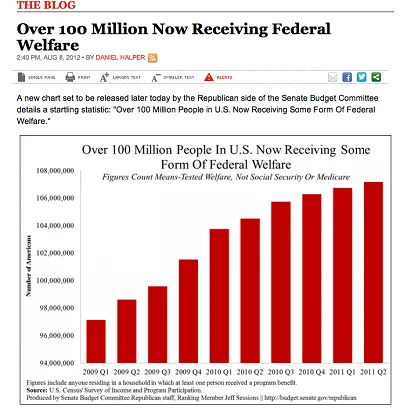

Here is a link to the hint.

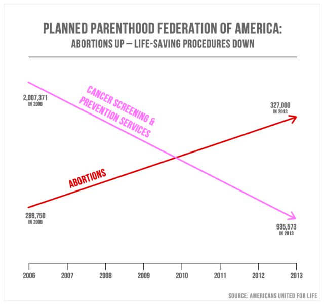

Here is a link to the hint.

3.

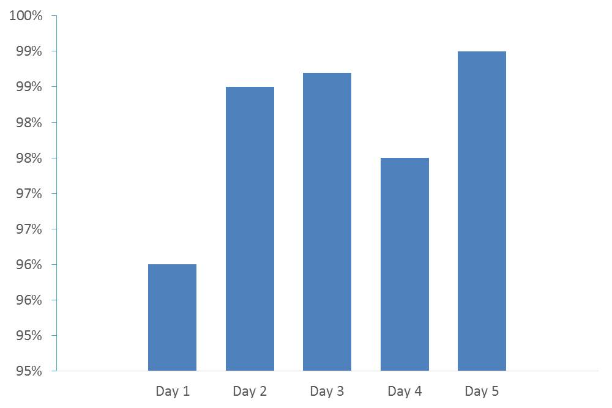

Here is a link to the hint. There are actually two issues with this figure, bonus points for identifying both (the bonus is that we will be impressed).

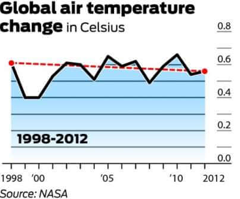

Here is a link to the hint.

# Part 3

Use the NC Births dataset from last week’s problem set to recreate the following figures:

1. A histogram of the weight of each baby (here I am using theme_classic(), you do not need to use the same theme but I recommend playing around with the various options to find one you like).

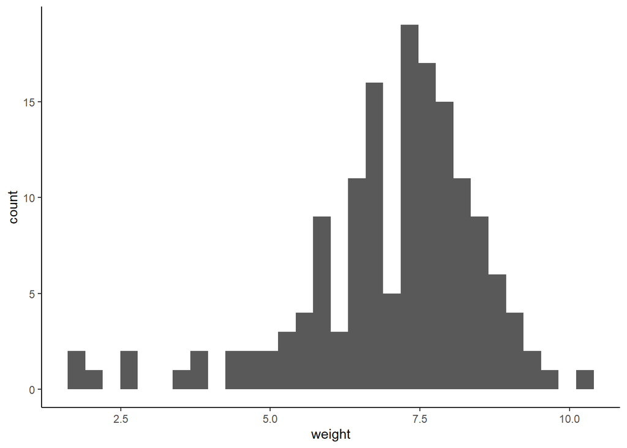

2. A histogram of the weight of each baby, colored by whether or not the mother smoked (hint, what is the difference between color and fill?). Note that this histogram defaults to being “stacked”. Make your histograms overlap by using “position=”identity” inside the histogram geom, and increase the transparency using alpha=0.5.

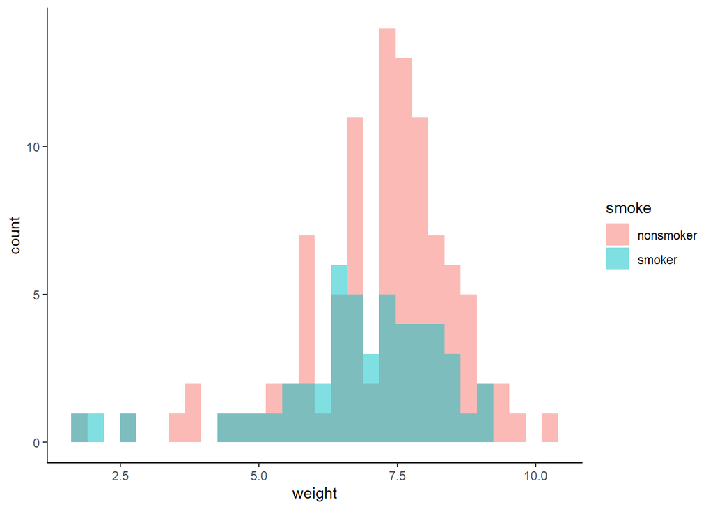

3. Recreate the above figure, but use either facet_wrap() or facet_grid() to facet by whether or not the mother smoked with a vertical layout (the example below uses facet_wrap, facet_grid will look slightly different).

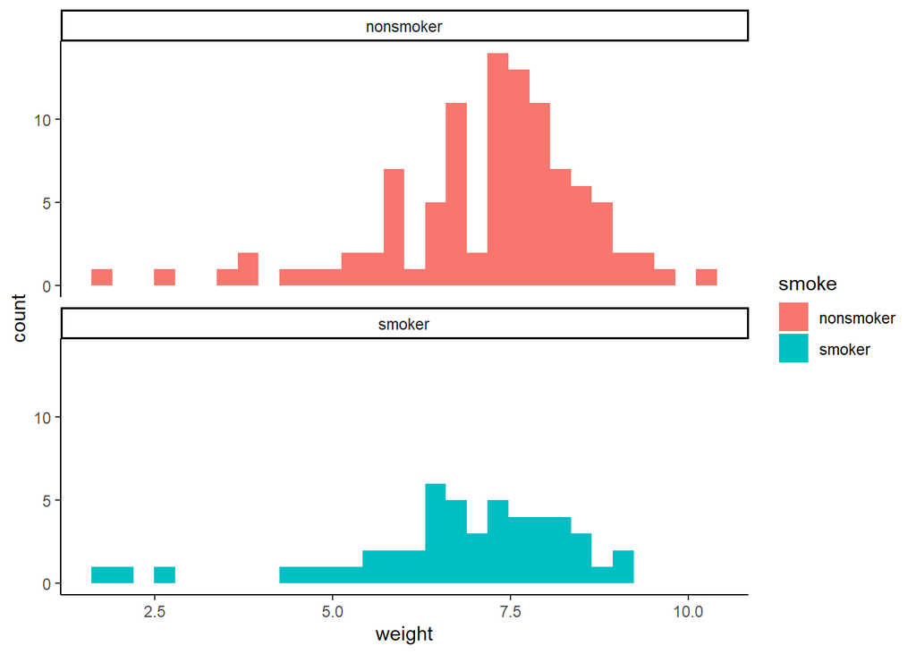

4. A box plot of the babies weights, separated by whether they were premature or full term

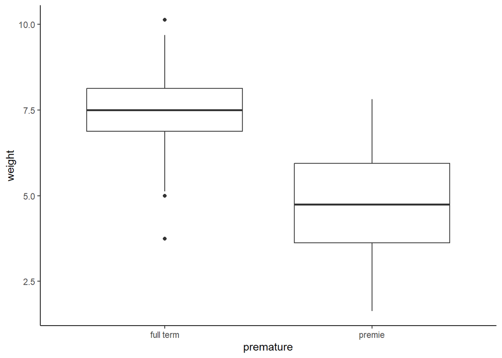

5. A box plot of the babies weights, separated by whether they were premature or full term and colored by whether or not the mother was a smoker.

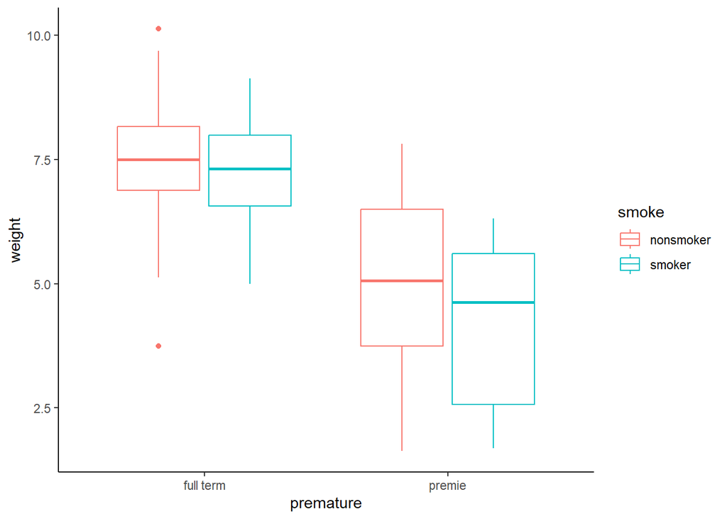

6. In five separate code chunks (so five new figures), regenerate the previous plot, but:

6.a Increase the size of all of the text (axis titles, axis labels, and legend title/labels). Use size=20.

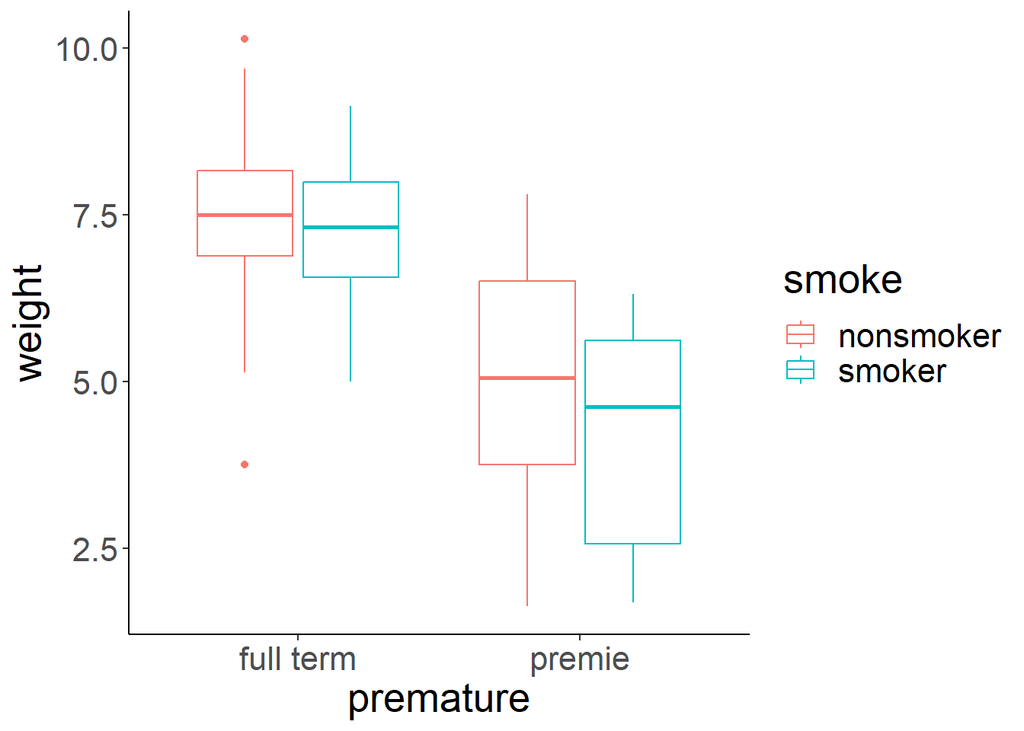

6.b Increase the size of the x and y axis titles ONLY. Use size=20.

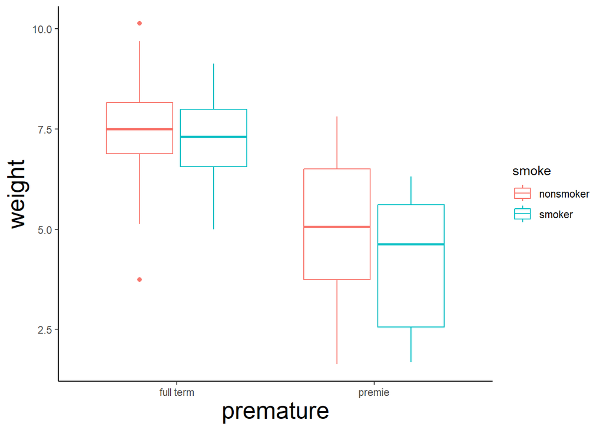

6.c Remove the x-axis title “premature” without removing the labels “full term” and “premie”

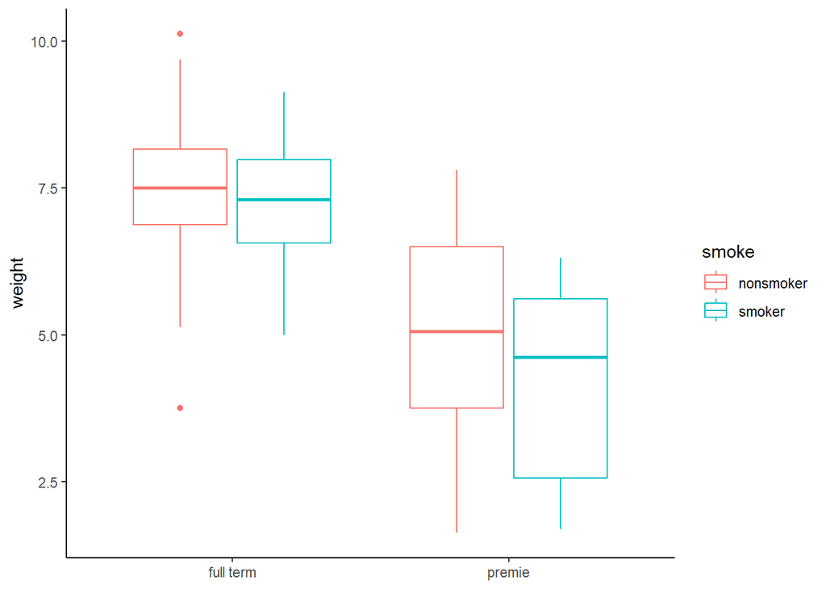

6.d Increase the labels (the numbers) and remove the tick-marks of the y-axis. Use size=20.

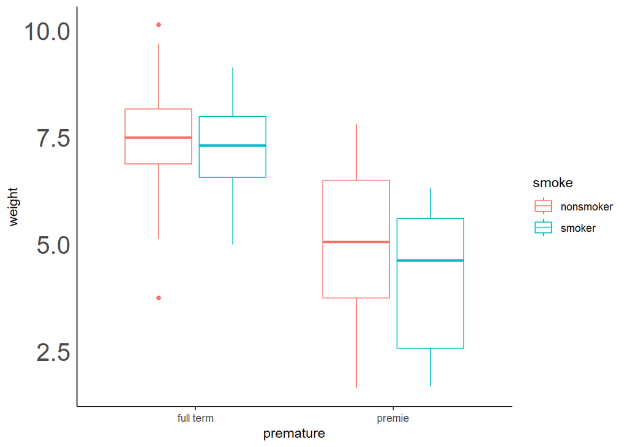

6.e Change the y-axis title from “weight” to “Babies Weight”

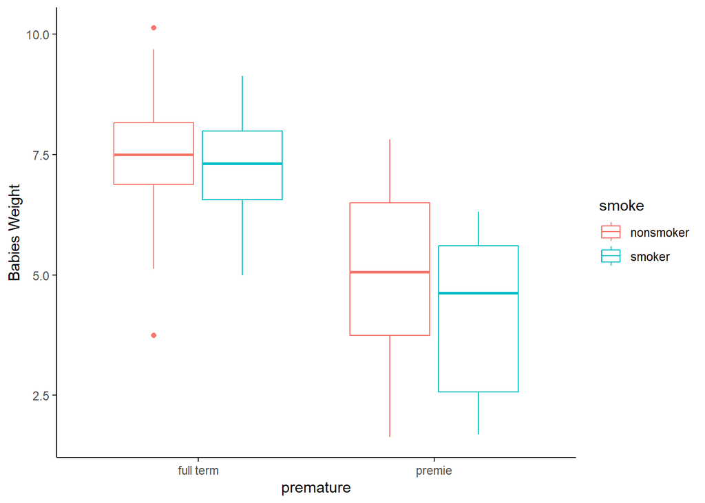

7. Make a scatterplot of the babies weight versus the weeks of gestation

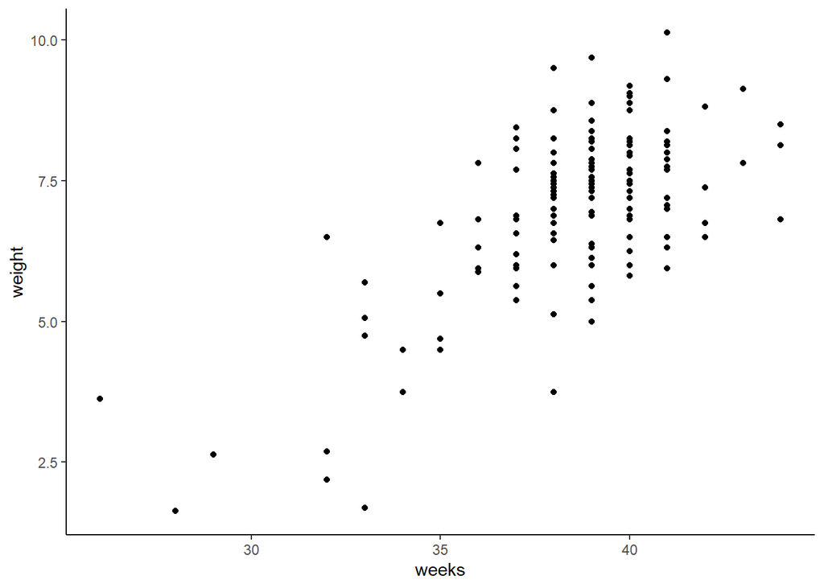

8. Recreate the previous figure but increase the size of the points (use size=3), increase the size of all text (use size=20), and add a LINEAR “best fit” line using geom_smooth().(Use a linear fit rather than the default loess)

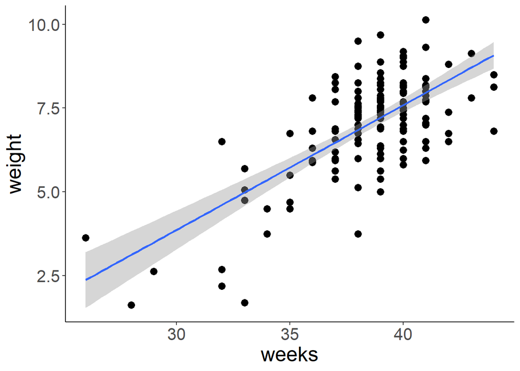

9. Repeat the previous figure, but remove the best fit line, and color the data by whether or not the mother was a smoker.

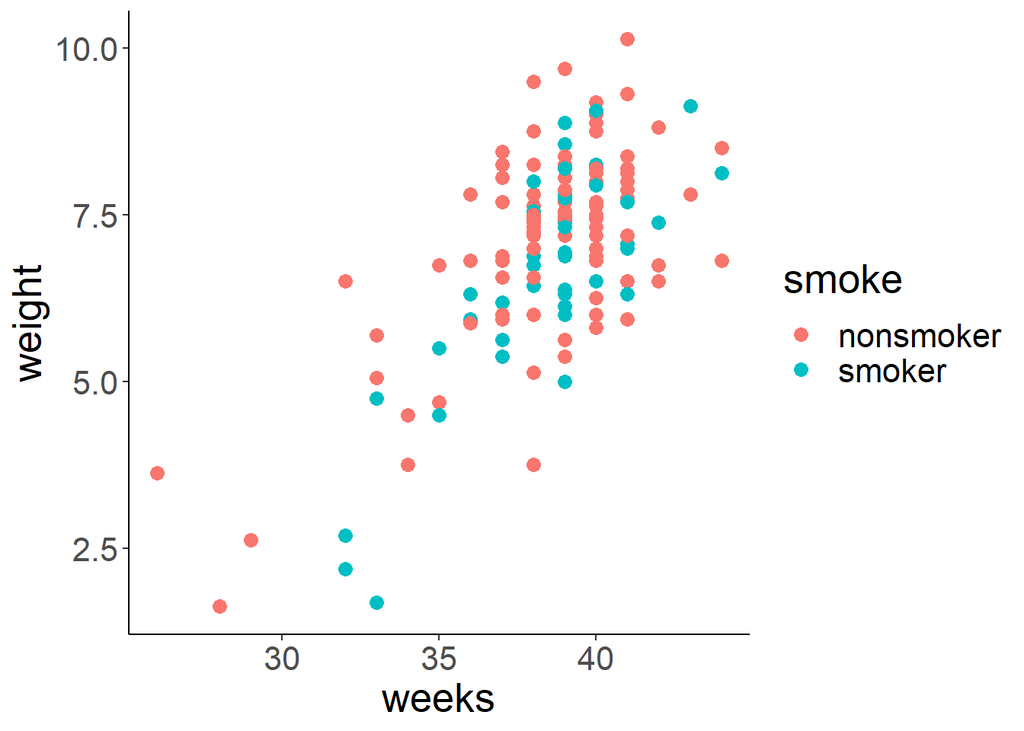

10. Repeat the previous figure, but add back in the LINEAR best fit line. Did it do what you were expecting?

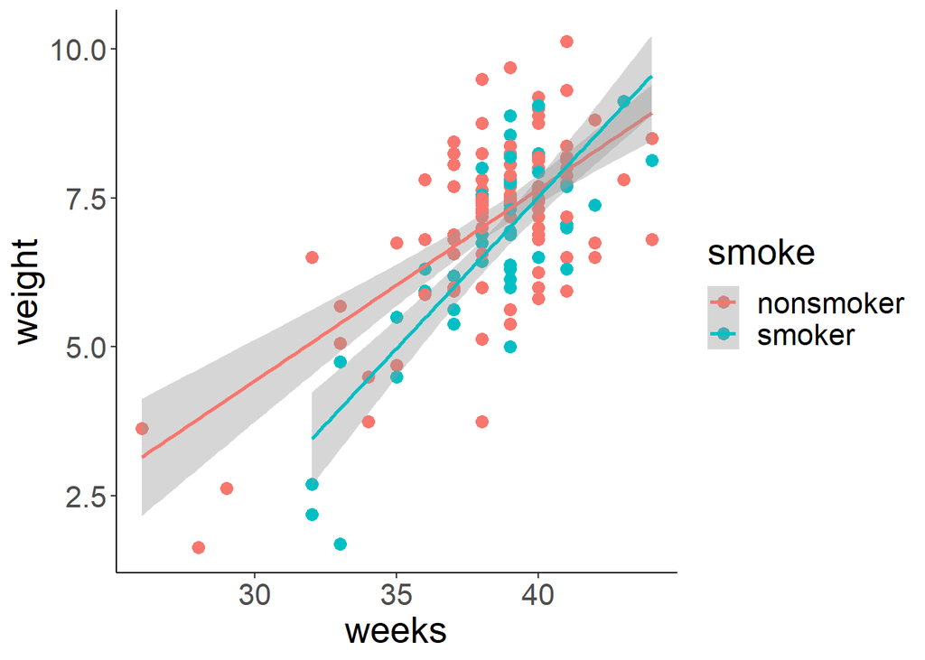

11. Repeat the figure you made in question 8, but color by the age of the mother, and increase the transparency of the points (use alpha=0.5). Did the best fit line do what you expected? Interpret the warning output–what do you think it means? Bonus points: add a slight jitter to the points to make them easier to see. (The bonus is that we will be very impressed)

```
## Warning: The following aesthetics were dropped during statistical transformation: colour
## ℹ This can happen when ggplot fails to infer the correct grouping structure in
##   the data.
## ℹ Did you forget to specify a `group` aesthetic or to convert a numerical
##   variable into a factor?
```

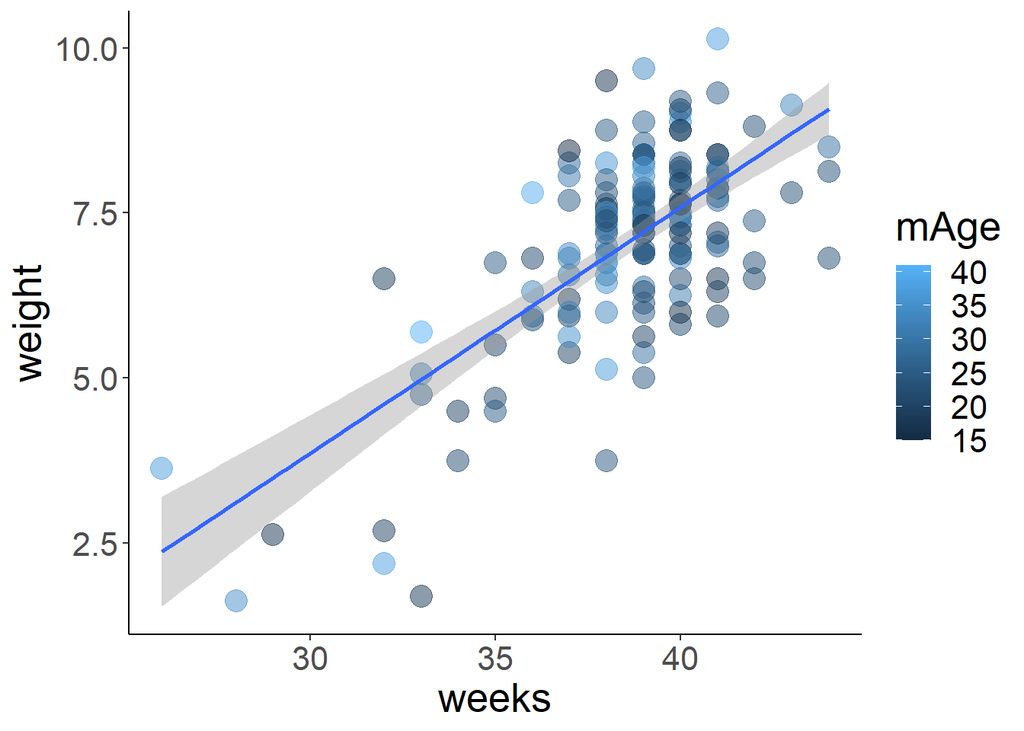

EXTRA Bonus point (*NOT* required): load the package “viridis” and change the color-scale bar using scale_color_viridis(). Here I have also added the jitter mentioned above.

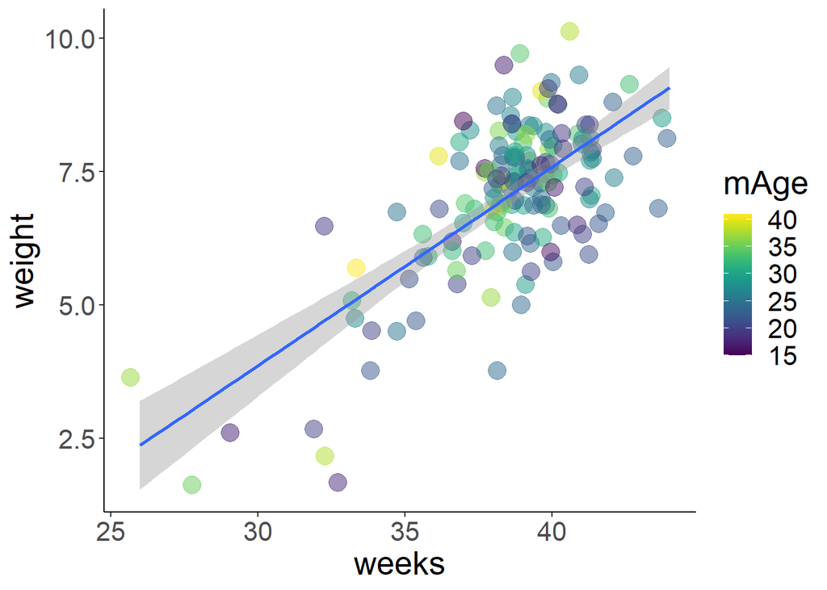

12. Make a figure of your own exploring an aspect of the data you are curious about (for example, is there a relationship between the number of visits the mother made and whether she was a smoker? Or is there a relationship between the mother’s age and how much weight she gained?). It’s up to you to pick the data you want to explore and how best to visualize it. State the question you are interested in, why you chose the type of figure you used, and what you believe the figure is showing.